# Naive Bayes Classification with R

[Naive Bayes classifiers](https://en.wikipedia.org/wiki/Naive_Bayes_classifier) are a family of simple “probabilistic classifiers” based on applying Bayes’ theorem with strong (naive) independence assumptions between the features. Naive Bayes methods are a set of supervised learning algorithms based on applying Bayes’ theorem with the “naive” assumption of conditional independence between every pair of features given the value of the class variable There is not a single algorithm for training such classifiers, but a family of algorithms based on a common principle: all naive Bayes classifiers assume that the value of a particular feature is independent of the value of any other feature, given the class variable. For example, a fruit may be considered to be an apple if it is red, round, and about 10 cm in diameter. A naive Bayes classifier considers each of these features to contribute independently to the probability that this fruit is an apple, regardless of any possible correlations between the color, roundness, and diameter features.

```r
library(naivebayes)
library(dplyr)
```

```r
library(ggplot2)
library(psych)
data <- read.csv("https://archive.ics.uci.edu/ml/machine-learning-databases/heart-disease/processed.cleveland.data",header=FALSE)
colnames(data) <- c("age","sex","cp","trestbps","chol","fbs","restecg","thalach","exang","oldpeak","slope","ca","thal","heart")
head(data)
```

|  | age | sex | cp | trestbps | chol | fbs | restecg | thalach | exang | oldpeak | slope | ca | thal | heart |
| --- | --- | --- | --- | --- | --- | --- | --- | --- | --- | --- | --- | --- | --- | --- |
| 1 | 63 | 1 | 1 | 145 | 233 | 1 | 2 | 150 | 0 | 2.3 | 3 | 0.0 | 6.0 | 0 |
| 2 | 67 | 1 | 4 | 160 | 286 | 0 | 2 | 108 | 1 | 1.5 | 2 | 3.0 | 3.0 | 2 |
| 3 | 67 | 1 | 4 | 120 | 229 | 0 | 2 | 129 | 1 | 2.6 | 2 | 2.0 | 7.0 | 1 |
| 4 | 37 | 1 | 3 | 130 | 250 | 0 | 0 | 187 | 0 | 3.5 | 3 | 0.0 | 3.0 | 0 |
| 5 | 41 | 0 | 2 | 130 | 204 | 0 | 2 | 172 | 0 | 1.4 | 1 | 0.0 | 3.0 | 0 |
| 6 | 56 | 1 | 2 | 120 | 236 | 0 | 0 | 178 | 0 | 0.8 | 1 | 0.0 | 3.0 | 0 |

```r
str(data)
```

```
## 'data.frame':    303 obs. of  14 variables:
##  $ age     : num  63 67 67 37 41 56 62 57 63 53 ...
##  $ sex     : num  1 1 1 1 0 1 0 0 1 1 ...
##  $ cp      : num  1 4 4 3 2 2 4 4 4 4 ...
##  $ trestbps: num  145 160 120 130 130 120 140 120 130 140 ...
##  $ chol    : num  233 286 229 250 204 236 268 354 254 203 ...
##  $ fbs     : num  1 0 0 0 0 0 0 0 0 1 ...
##  $ restecg : num  2 2 2 0 2 0 2 0 2 2 ...
##  $ thalach : num  150 108 129 187 172 178 160 163 147 155 ...
##  $ exang   : num  0 1 1 0 0 0 0 1 0 1 ...
##  $ oldpeak : num  2.3 1.5 2.6 3.5 1.4 0.8 3.6 0.6 1.4 3.1 ...
##  $ slope   : num  3 2 2 3 1 1 3 1 2 3 ...
##  $ ca      : Factor w/ 5 levels "?","0.0","1.0",..: 2 5 4 2 2 2 4 2 3 2 ...
##  $ thal    : Factor w/ 4 levels "?","3.0","6.0",..: 3 2 4 2 2 2 2 2 4 4 ...
##  $ heart   : int  0 2 1 0 0 0 3 0 2 1 ...
```

```r
data$heart = as.factor(ifelse(data$heart==0,"0","1"))
str(data)
```

```
## 'data.frame':    303 obs. of  14 variables:
##  $ age     : num  63 67 67 37 41 56 62 57 63 53 ...
##  $ sex     : num  1 1 1 1 0 1 0 0 1 1 ...
##  $ cp      : num  1 4 4 3 2 2 4 4 4 4 ...
##  $ trestbps: num  145 160 120 130 130 120 140 120 130 140 ...
##  $ chol    : num  233 286 229 250 204 236 268 354 254 203 ...
##  $ fbs     : num  1 0 0 0 0 0 0 0 0 1 ...
##  $ restecg : num  2 2 2 0 2 0 2 0 2 2 ...
##  $ thalach : num  150 108 129 187 172 178 160 163 147 155 ...
##  $ exang   : num  0 1 1 0 0 0 0 1 0 1 ...
##  $ oldpeak : num  2.3 1.5 2.6 3.5 1.4 0.8 3.6 0.6 1.4 3.1 ...
##  $ slope   : num  3 2 2 3 1 1 3 1 2 3 ...
##  $ ca      : Factor w/ 5 levels "?","0.0","1.0",..: 2 5 4 2 2 2 4 2 3 2 ...
##  $ thal    : Factor w/ 4 levels "?","3.0","6.0",..: 3 2 4 2 2 2 2 2 4 4 ...
##  $ heart   : Factor w/ 2 levels "0","1": 1 2 2 1 1 1 2 1 2 2 ...
```

```r
xtabs(~heart+sex,data=data)
```

```
##      sex
## heart   0   1
##     0  72  92
##     1  25 114
```

```r
dim(data)
```

```
## [1] 303  14
```

```r
summary(data)
```

```
##       age             sex               cp           trestbps
##  Min.   :29.00   Min.   :0.0000   Min.   :1.000   Min.   : 94.0
##  1st Qu.:48.00   1st Qu.:0.0000   1st Qu.:3.000   1st Qu.:120.0
##  Median :56.00   Median :1.0000   Median :3.000   Median :130.0
##  Mean   :54.44   Mean   :0.6799   Mean   :3.158   Mean   :131.7
##  3rd Qu.:61.00   3rd Qu.:1.0000   3rd Qu.:4.000   3rd Qu.:140.0
##  Max.   :77.00   Max.   :1.0000   Max.   :4.000   Max.   :200.0
##       chol            fbs            restecg          thalach
##  Min.   :126.0   Min.   :0.0000   Min.   :0.0000   Min.   : 71.0
##  1st Qu.:211.0   1st Qu.:0.0000   1st Qu.:0.0000   1st Qu.:133.5
##  Median :241.0   Median :0.0000   Median :1.0000   Median :153.0
##  Mean   :246.7   Mean   :0.1485   Mean   :0.9901   Mean   :149.6
##  3rd Qu.:275.0   3rd Qu.:0.0000   3rd Qu.:2.0000   3rd Qu.:166.0
##  Max.   :564.0   Max.   :1.0000   Max.   :2.0000   Max.   :202.0
##      exang           oldpeak         slope         ca       thal
##  Min.   :0.0000   Min.   :0.00   Min.   :1.000   ?  :  4   ?  :  2
##  1st Qu.:0.0000   1st Qu.:0.00   1st Qu.:1.000   0.0:176   3.0:166
##  Median :0.0000   Median :0.80   Median :2.000   1.0: 65   6.0: 18
##  Mean   :0.3267   Mean   :1.04   Mean   :1.601   2.0: 38   7.0:117
##  3rd Qu.:1.0000   3rd Qu.:1.60   3rd Qu.:2.000   3.0: 20
##  Max.   :1.0000   Max.   :6.20   Max.   :3.000
##  heart
##  0:164
##  1:139
##
##
##
##
```

lets convert sex to factor

```r
data$sex <- as.factor(data$sex)
data$cp <- as.factor(data$cp)
summary(data)
```

```
##       age        sex     cp         trestbps          chol
##  Min.   :29.00   0: 97   1: 23   Min.   : 94.0   Min.   :126.0
##  1st Qu.:48.00   1:206   2: 50   1st Qu.:120.0   1st Qu.:211.0
##  Median :56.00           3: 86   Median :130.0   Median :241.0
##  Mean   :54.44           4:144   Mean   :131.7   Mean   :246.7
##  3rd Qu.:61.00                   3rd Qu.:140.0   3rd Qu.:275.0
##  Max.   :77.00                   Max.   :200.0   Max.   :564.0
##       fbs            restecg          thalach          exang
##  Min.   :0.0000   Min.   :0.0000   Min.   : 71.0   Min.   :0.0000
##  1st Qu.:0.0000   1st Qu.:0.0000   1st Qu.:133.5   1st Qu.:0.0000
##  Median :0.0000   Median :1.0000   Median :153.0   Median :0.0000
##  Mean   :0.1485   Mean   :0.9901   Mean   :149.6   Mean   :0.3267
##  3rd Qu.:0.0000   3rd Qu.:2.0000   3rd Qu.:166.0   3rd Qu.:1.0000
##  Max.   :1.0000   Max.   :2.0000   Max.   :202.0   Max.   :1.0000
##     oldpeak         slope         ca       thal     heart
##  Min.   :0.00   Min.   :1.000   ?  :  4   ?  :  2   0:164
##  1st Qu.:0.00   1st Qu.:1.000   0.0:176   3.0:166   1:139
##  Median :0.80   Median :2.000   1.0: 65   6.0: 18
##  Mean   :1.04   Mean   :1.601   2.0: 38   7.0:117
##  3rd Qu.:1.60   3rd Qu.:2.000   3.0: 20
##  Max.   :6.20   Max.   :3.000
```

In order to perform Naive bayes there should not be high correlation between independent variables. Lets see

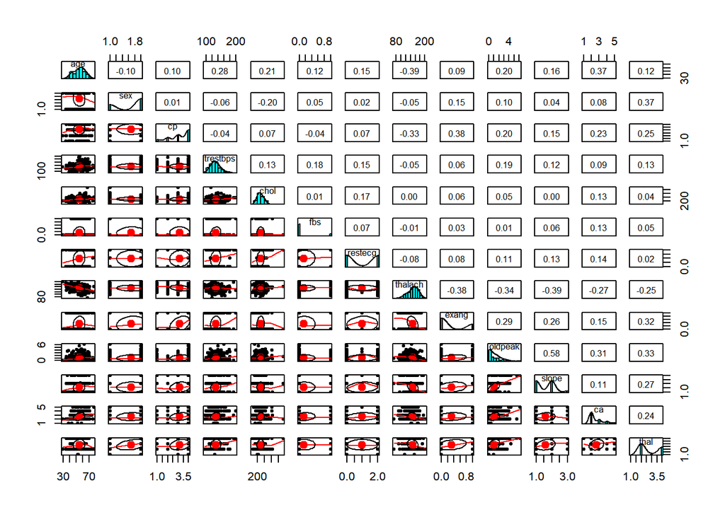

```r
pairs.panels(data[-14])
```

```r
data1 <- data[,c(1,2,3,5,14)]
str(data1)
```

```
## 'data.frame':    303 obs. of  5 variables:
##  $ age  : num  63 67 67 37 41 56 62 57 63 53 ...
##  $ sex  : Factor w/ 2 levels "0","1": 2 2 2 2 1 2 1 1 2 2 ...
##  $ cp   : Factor w/ 4 levels "1","2","3","4": 1 4 4 3 2 2 4 4 4 4 ...
##  $ chol : num  233 286 229 250 204 236 268 354 254 203 ...
##  $ heart: Factor w/ 2 levels "0","1": 1 2 2 1 1 1 2 1 2 2 ...
```

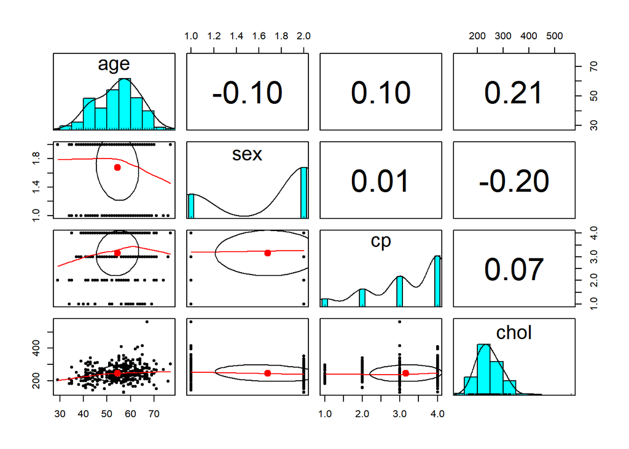

```r
pairs.panels(data1[-5])
```

So there doesn’t seem to be any correlation

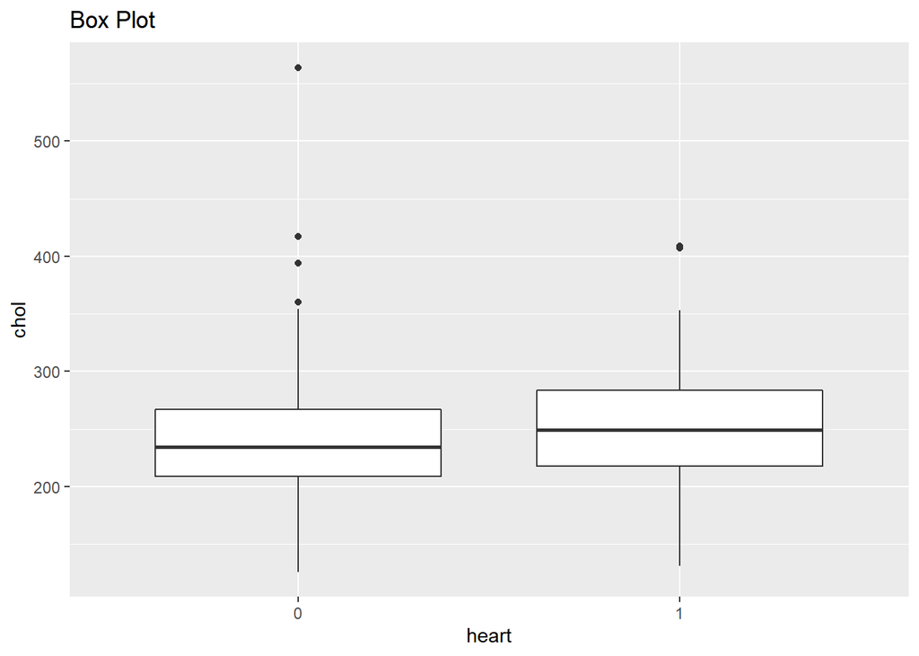

```r
data1 %>%
  ggplot(aes(x=heart,y=chol,fil=heart)) +
  geom_boxplot() +
  ggtitle("Box Plot")
```

There seems to be some overlap, so the model might not be very accurate

Lets look at other variables

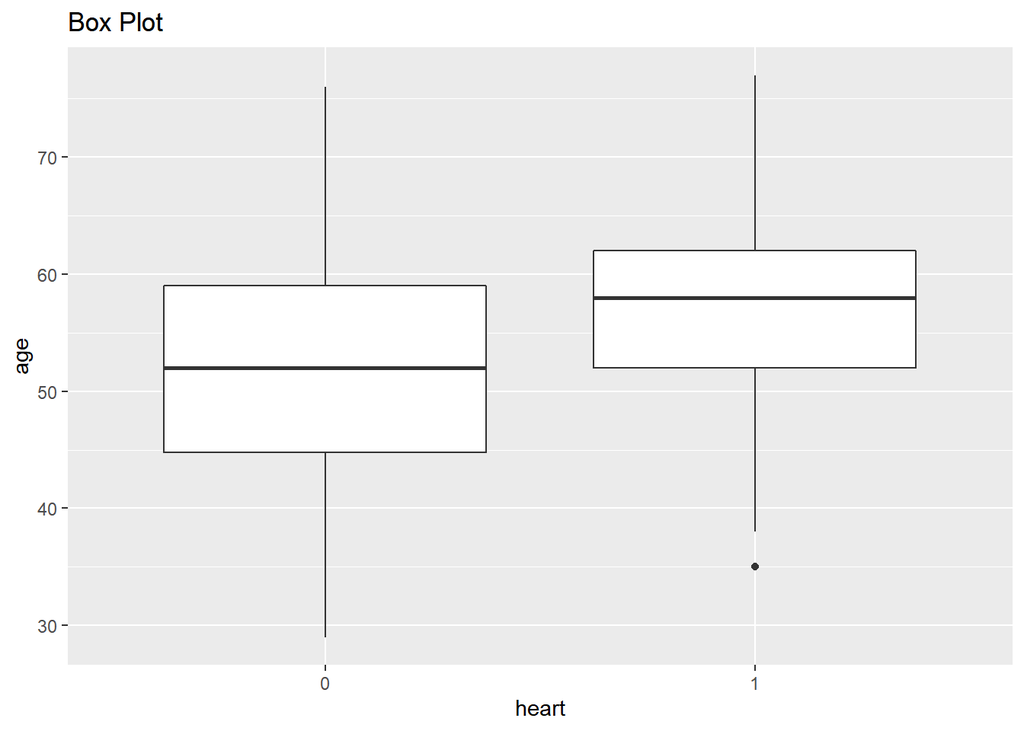

```r
data1 %>%
  ggplot(aes(x=heart,y=age,fil=heart)) +
  geom_boxplot() +
  ggtitle("Box Plot")
```

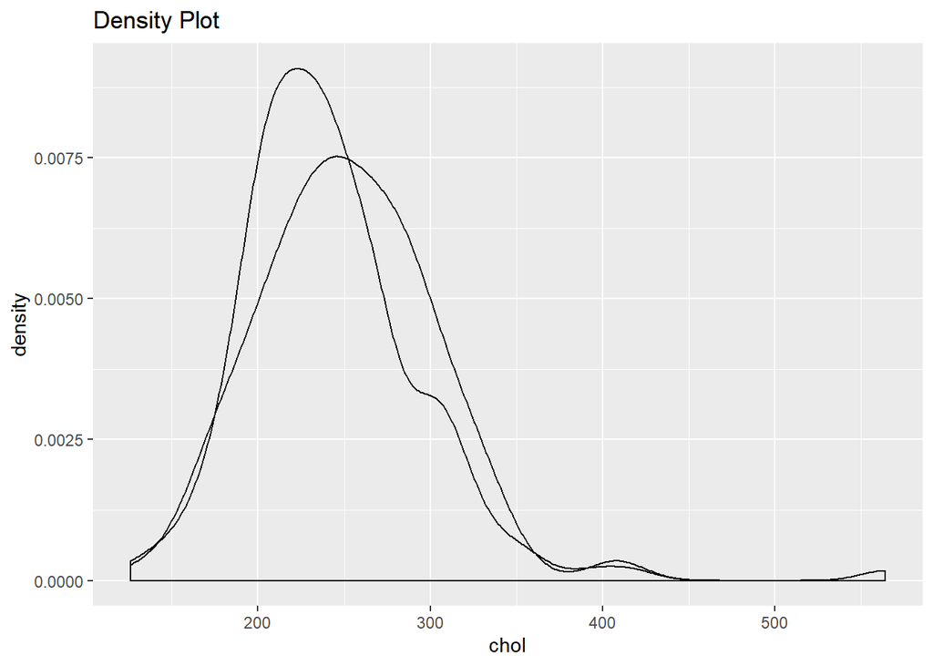

```r
data1 %>%
  ggplot(aes(x=chol,fil=heart)) +
  geom_density(alpha=0.8,color="black") +
  ggtitle("Density Plot")
```

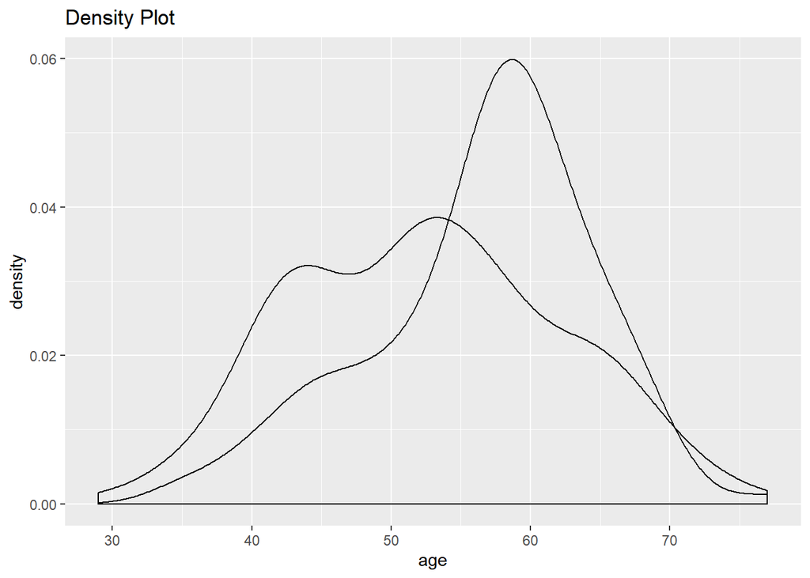

```r
data1 %>%
  ggplot(aes(x=age,fil=heart)) +
  geom_density(alpha=0.8,color="black") +
  ggtitle("Density Plot")
```

```r
set.seed(1234)
marker <- sample(2,nrow(data1),replace=T, prob=c(0.75,0.25))
traind <- data1[marker==1,]
testd <- data1[marker==2,]
```

Bayes Theorem: P(A|B) = (P(A) * P(B|A))/P(B) Where A & B are independent

```r
model <- naive_bayes(heart~.,data=traind)
model
```

```
##
## ================================ Naive Bayes =================================
##
##  Call:
## naive_bayes.formula(formula = heart ~ ., data = traind)
##
## ------------------------------------------------------------------------------
##
## Laplace smoothing: 0
##
## ------------------------------------------------------------------------------
##
##  A priori probabilities:
##
##        0        1
## 0.525641 0.474359
##
## ------------------------------------------------------------------------------
##
##  Tables:
##
## ------------------------------------------------------------------------------
##  ::: age (Gaussian)
## ------------------------------------------------------------------------------
##
## age            0         1
##   mean 52.495935 56.207207
##   sd    9.416914  7.735534
##
## ------------------------------------------------------------------------------
##  ::: sex (Bernoulli)
## ------------------------------------------------------------------------------
##
## sex         0         1
##   0 0.4715447 0.1441441
##   1 0.5284553 0.8558559
##
## ------------------------------------------------------------------------------
##  ::: cp (Categorical)
## ------------------------------------------------------------------------------
##
## cp           0          1
##   1 0.08943089 0.05405405
##   2 0.24390244 0.07207207
##   3 0.40650407 0.15315315
##   4 0.26016260 0.72072072
##
## ------------------------------------------------------------------------------
##  ::: chol (Gaussian)
## ------------------------------------------------------------------------------
##
## chol           0         1
##   mean 247.96748 249.18018
##   sd    56.95597  47.31331
##
## ------------------------------------------------------------------------------
```

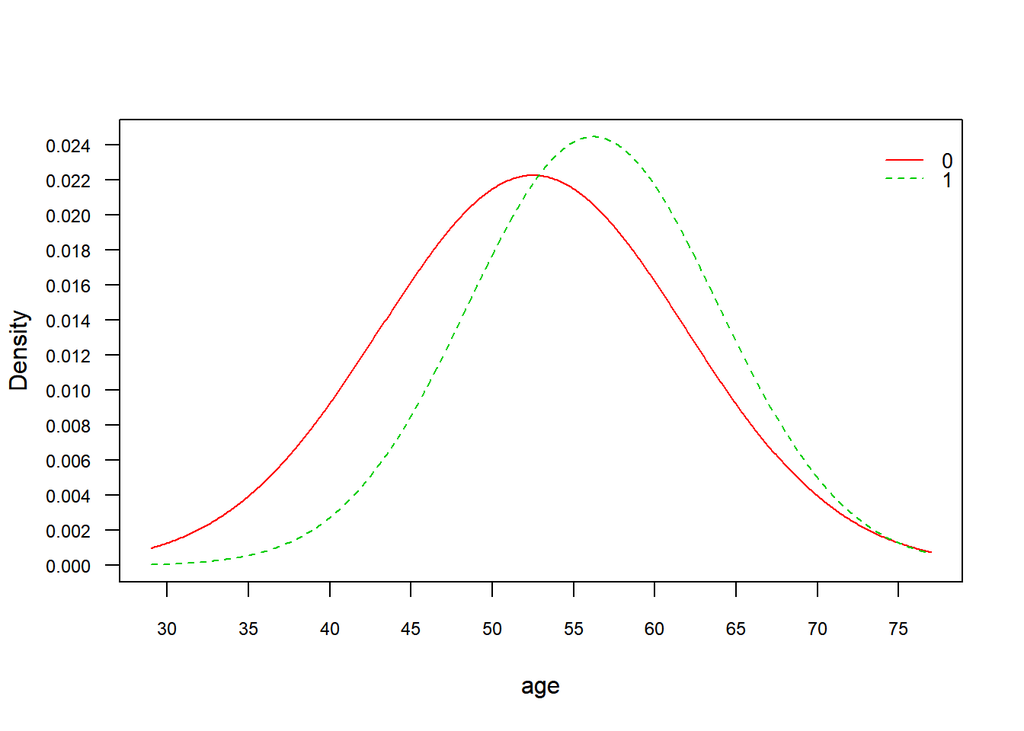

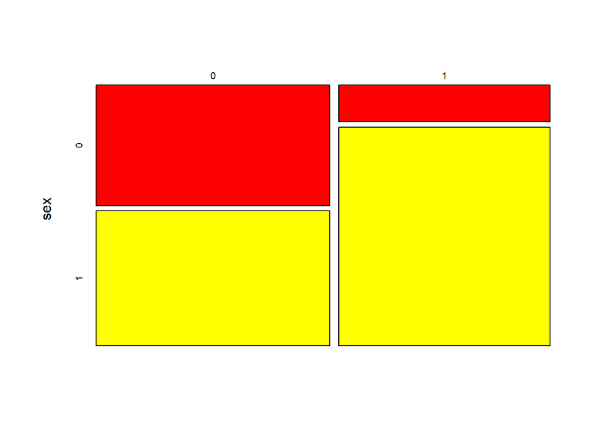

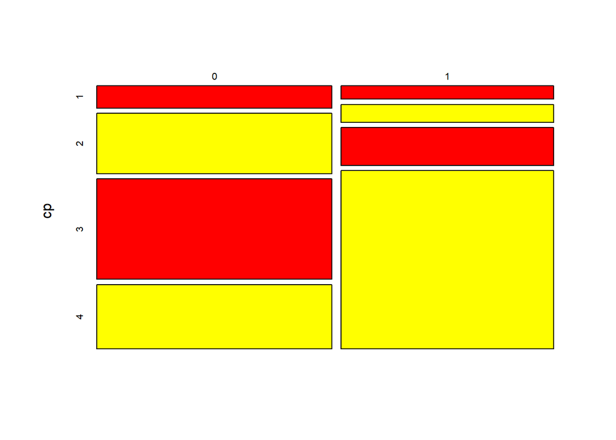

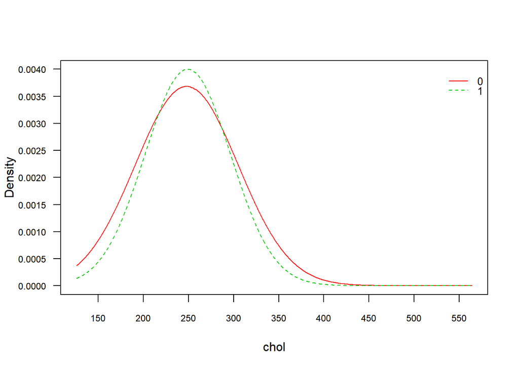

```r
plot(model)
```

Lets do prediction and see confusion matrix

```r
prmodel <- predict(model,traind)
(tab1 <- table(prmodel,traind$heart))
```

```
##
## prmodel  0  1
##       0 96 33
##       1 27 78
```

the prediction accuracy is

```r
sum(diag(tab1))/sum(tab1)
```

```
## [1] 0.7435897
```

Lets check same for test data

```r
prmodel <- predict(model,testd)
(tab1 <- table(prmodel,testd$heart))
```

```
##
## prmodel  0  1
##       0 33  7
##       1  8 21
```

and prediction accuracy for test dataset

```r
sum(diag(tab1))/sum(tab1)
```

```
## [1] 0.7826087
```

We can also use kernel based densities while training the model and they usually perform better when numerical continous variables are normally distributed

```r
model <- naive_bayes(heart~.,data=traind,usekernel = T)
prmodel <- predict(model,traind)
(tab1 <- table(prmodel,traind$heart))
```

```
##
## prmodel  0  1
##       0 96 26
##       1 27 85
```

```r
sum(diag(tab1))/sum(tab1)
```

```
## [1] 0.7735043
```

So that is 77% accuracy with Kernel vs 74 without